# NFL-Statistics

## Introduction

Regardless of whether or not you are interested in sports, our group believes that everybody can find some degree of interest in sports statistics. We chose to gather data about the NFL because of the abundance of high quality data that we could access. We hope to highlight surprising and interesting connections between NFL datasets. In this project we are specifically focusing on the arrests.csv file where we are analyzing how different variables(denoted by the column values) relate to the arrests of NFL players.

## Summary

We created summary information from our NFL arrests dataset, which is a dataset listing a bunch of NFL games and some relevant information, and the number of arrests that occured in those games. The mean home score was 23.9343936, the mean away score was 21.1153082, the mean score difference 2.8190855, the proportion of OT to non OT games was 0.0586481, and the mean number of arrests were 6.5662526.

We also included a table showing the number of occurrences of each day in our arrests dataset.

| col | v |
| --- | --- |
| mean_home_score | 23.9343936 |
| mean_away_score | 21.1153082 |
| mean_score_difference | 2.8190855 |
| proportion_OT | 0.0586481 |
| mean_arrests | 6.5662526 |

Summary info table:

| day_of_week | day_occurrences |
| --- | --- |
| Monday | 70 |
| Saturday | 16 |
| Sunday | 855 |
| Thursday | 64 |
| Wednesday | 1 |

Table detailing aggregate function

## Results

### Arrest by Home Score

The purpose of the first chart was to see if there was a relationship between home scores and arrests. We thought a scatterplot would be a good way to present this information as it is easy to read and make quick interpretations.

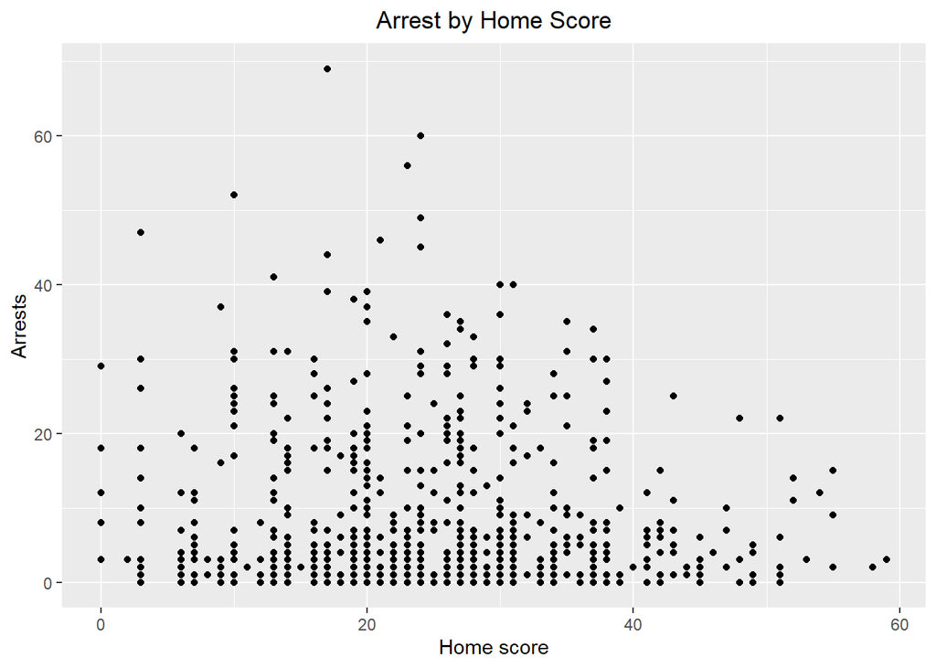

### Number of arrests per week

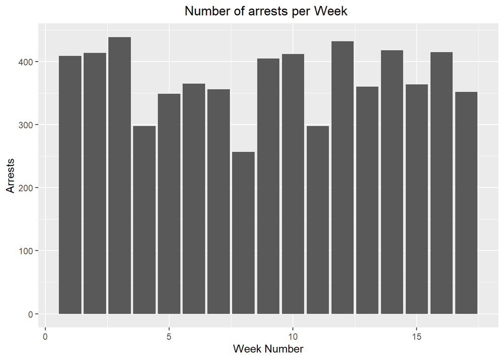

### Number of crimes for each day of week

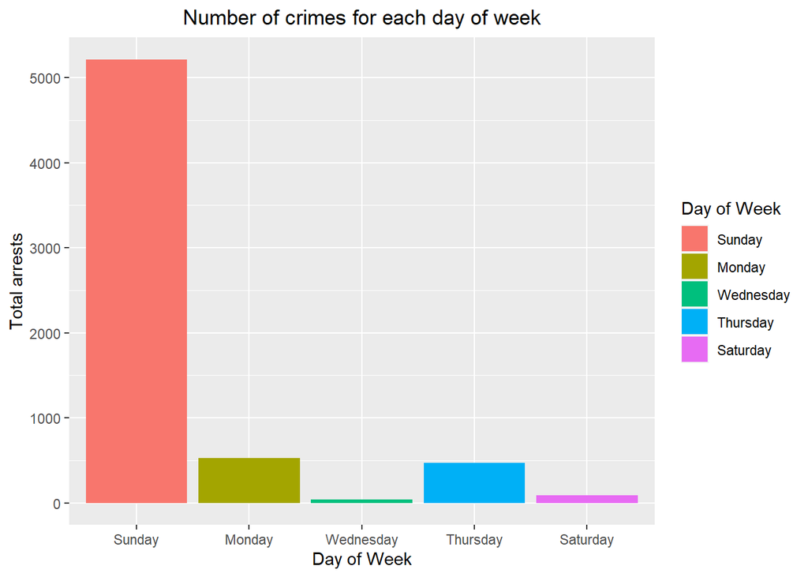